# Prosper Loan Data

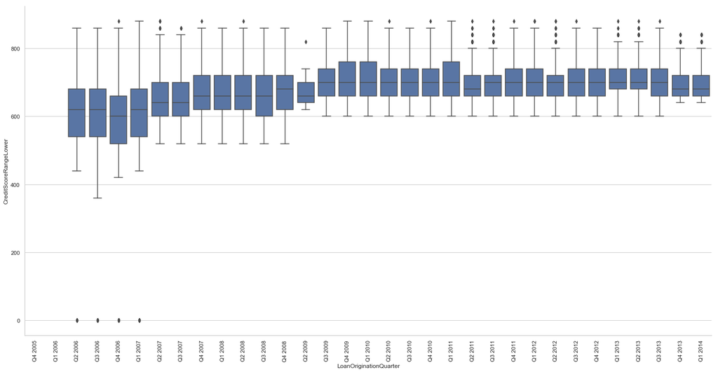

```python
#bivariate plot of credit score range lower and loan origination quarter in order categorical type
quarter = ['Q4 2005', 'Q1 2006', 'Q2 2006', 'Q3 2006', 'Q4 2006', 'Q1 2007', 'Q2 2007', 'Q3 2007', 'Q4 2007', 'Q1 2008', 'Q2 2008', 'Q3 2008', 'Q4 2008',
          'Q2 2009', 'Q3 2009', 'Q4 2009', 'Q1 2010', 'Q2 2010', 'Q3 2010', 'Q4 2010', 'Q1 2011', 'Q2 2011', 'Q3 2011', 'Q4 2011', 'Q1 2012', 'Q2 2012', 'Q3 2012', 'Q4 2012',
          'Q1 2013', 'Q2 2013', 'Q3 2013', 'Q4 2013', 'Q1 2014']
qrt_cat = pd.api.types.CategoricalDtype(ordered = True, categories = quarter)
prosperLoanData['LoanOriginationQuarter'] = prosperLoanData['LoanOriginationQuarter'].astype(qrt_cat)

prosperLoanData = prosperLoanData.loc[prosperLoanData['LoanOriginationQuarter'].isin(['Q4 2005', 'Q1 2006', 'Q2 2006', 'Q3 2006', 'Q4 2006', 'Q1 2007', 'Q2 2007', 'Q3 2007', 'Q4 2007', 'Q1 2008', 'Q2 2008', 'Q3 2008', 'Q4 2008',
          'Q2 2009', 'Q3 2009', 'Q4 2009', 'Q1 2010', 'Q2 2010', 'Q3 2010', 'Q4 2010', 'Q1 2011', 'Q2 2011', 'Q3 2011', 'Q4 2011', 'Q1 2012', 'Q2 2012', 'Q3 2012', 'Q4 2012',
          'Q1 2013', 'Q2 2013', 'Q3 2013', 'Q4 2013', 'Q1 2014'])]

base_color = sb.color_palette()[0]
sns.set(style="whitegrid")
sns.catplot(x='LoanOriginationQuarter', y='CreditScoreRangeLower', kind="box", data=prosperLoanData, height=10, aspect=2, color=base_color);
plt.xticks(rotation=90);
```

```python
prosperLoanData['CreditScoreRangeLower'].value_counts()
```

```
640.0    2696
680.0    2020
620.0    1964
600.0    1933
660.0    1805
700.0    1553
720.0    1534
760.0    1154
740.0    1147
520.0    1136
560.0     992
580.0     836
780.0     756
540.0     735
800.0     414
820.0     289
840.0     131
860.0      63
880.0       7
Name: CreditScoreRangeLower, dtype: int64
```

Looking at the credit score over time, it is clear that Prosper changed its policies from one that had no minimum credit score to one that had very strict lower limits. That lower limit rose over time from 520 in Q2 2007 to 600 in Q3 2009 (after the credit crisis) to 640 most recently.

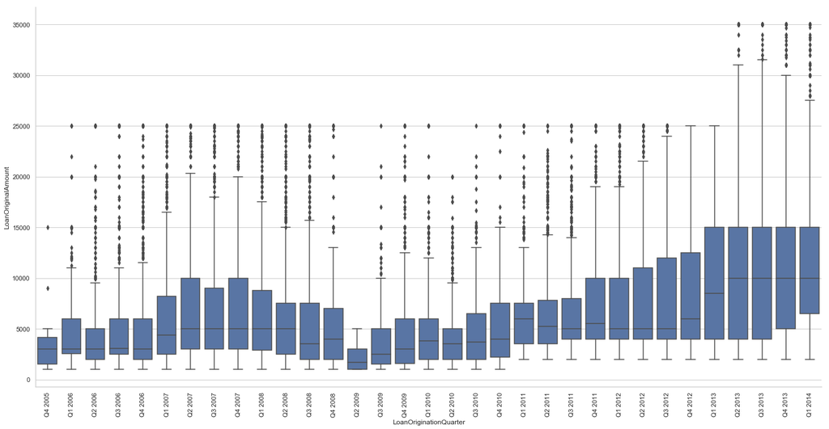

```python
#bivariate plot of loan original amount and loan origination quarter in order categorical type
quarter = ['Q4 2005', 'Q1 2006', 'Q2 2006', 'Q3 2006', 'Q4 2006', 'Q1 2007', 'Q2 2007', 'Q3 2007', 'Q4 2007', 'Q1 2008', 'Q2 2008', 'Q3 2008', 'Q4 2008',
          'Q2 2009', 'Q3 2009', 'Q4 2009', 'Q1 2010', 'Q2 2010', 'Q3 2010', 'Q4 2010', 'Q1 2011', 'Q2 2011', 'Q3 2011', 'Q4 2011', 'Q1 2012', 'Q2 2012', 'Q3 2012', 'Q4 2012',
          'Q1 2013', 'Q2 2013', 'Q3 2013', 'Q4 2013', 'Q1 2014']
qrt_cat = pd.api.types.CategoricalDtype(ordered = True, categories = quarter)
prosperLoanData['LoanOriginationQuarter'] = prosperLoanData['LoanOriginationQuarter'].astype(qrt_cat)

prosperLoanData = prosperLoanData.loc[prosperLoanData['LoanOriginationQuarter'].isin(['Q4 2005', 'Q1 2006', 'Q2 2006', 'Q3 2006', 'Q4 2006', 'Q1 2007', 'Q2 2007', 'Q3 2007', 'Q4 2007', 'Q1 2008', 'Q2 2008', 'Q3 2008', 'Q4 2008',
          'Q2 2009', 'Q3 2009', 'Q4 2009', 'Q1 2010', 'Q2 2010', 'Q3 2010', 'Q4 2010', 'Q1 2011', 'Q2 2011', 'Q3 2011', 'Q4 2011', 'Q1 2012', 'Q2 2012', 'Q3 2012', 'Q4 2012',
          'Q1 2013', 'Q2 2013', 'Q3 2013', 'Q4 2013', 'Q1 2014'])]

base_color = sb.color_palette()[0]
sns.set(style="whitegrid")
sns.catplot(x='LoanOriginationQuarter', y='LoanOriginalAmount', kind="box", data=prosperLoanData, height=10, aspect=2, color=base_color);
plt.xticks(rotation=90);
```

From the prior graph credit score when Prosper changed its policies, the loan amount rose over time after the credit crisis.

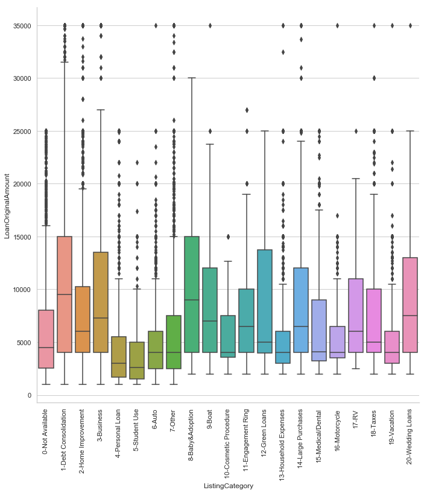

```python
#bivariate plot of listing category and loan original amount, create xstick labels
sns.set(style="whitegrid")
g = sns.catplot(x='ListingCategory', y='LoanOriginalAmount', kind="box", data=prosperLoanData, height=10, aspect=1);
xlabels = ['0-Not Available', '1-Debt Consolidation', '2-Home Improvement', '3-Business', '4-Personal Loan', '5-Student Use',
           '6-Auto', '7-Other', '8-Baby&Adoption', '9-Boat', '10-Cosmetic Procedure', '11-Engagement Ring', '12-Green Loans',
           '13-Household Expenses', '14-Large Purchases', '15-Medical/Dental', '16-Motorcycle', '17-RV', '18-Taxes', '19-Vacation',
           '20-Wedding Loans']
g.set_xticklabels(xlabels, rotation=90);
```

1-Debt Consolidation and 8-Baby/Adoption are the category with the top amounts. ~$9k on average.

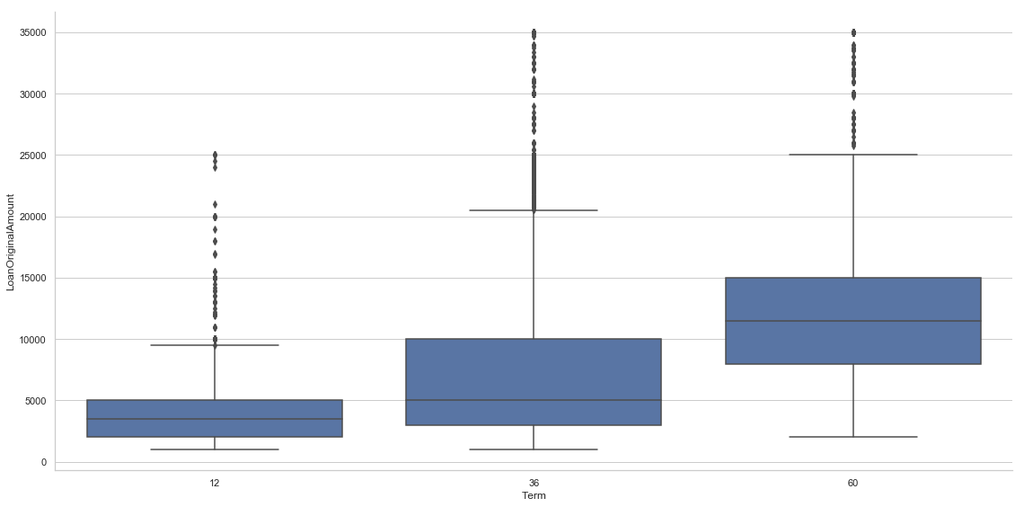

```python
#bivariate plot of term and loan original amount
base_color = sb.color_palette()[0]
sns.set(style="whitegrid")
sns.catplot(x='Term', y='LoanOriginalAmount', kind="box", data=prosperLoanData, height=8, aspect=2, color=base_color);
```

As the term is longer, the loan amounts are larger.

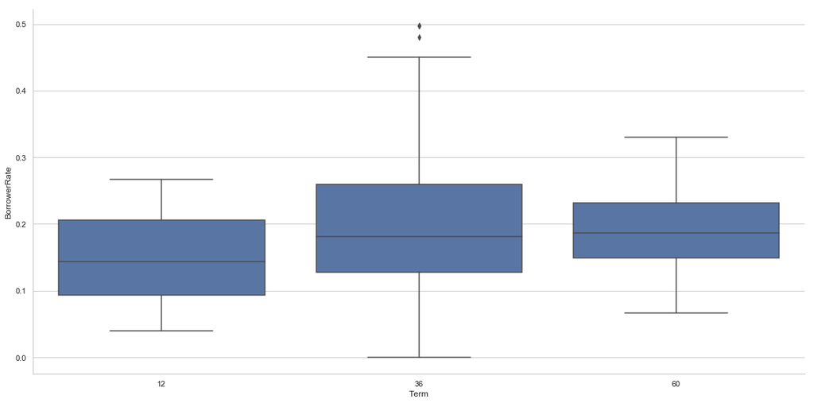

```python
#bivariate plot of term and borrower interest rate
base_color = sb.color_palette()[0]
sns.set(style="whitegrid")
sns.catplot(x='Term', y='BorrowerRate', kind="box", data=prosperLoanData, height=8, aspect=2, color=base_color);
```

```python
prosperLoanData['Term'].describe()
```

```
count    113937.000000
mean         40.830248
std          10.436212
min          12.000000
25%          36.000000
50%          36.000000
75%          36.000000
max          60.000000
Name: Term, dtype: float64
```

The 3 year term is not necessarily more expensive. The mean interest rate moves up slightly at the 5 year term and the variance is smaller.

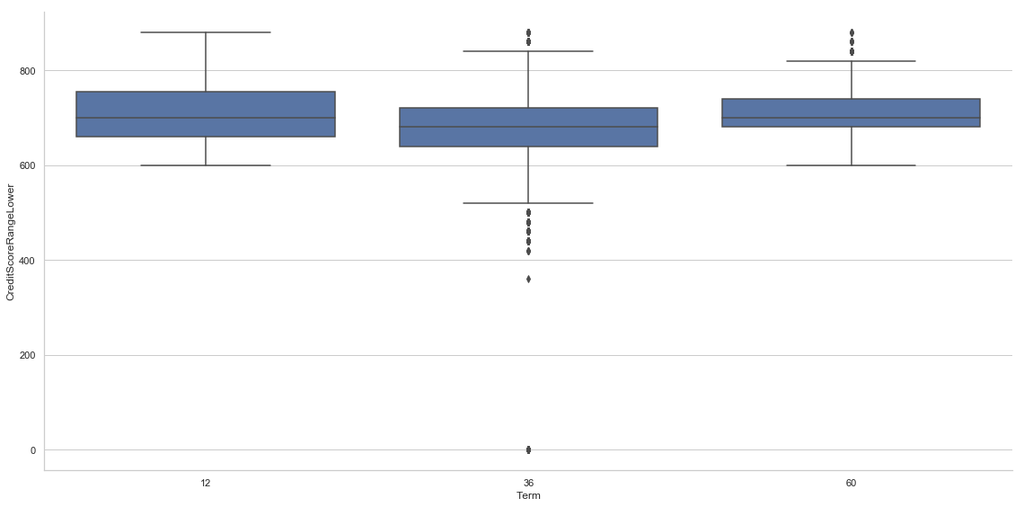

```python
#bivariate plot of term and credit score range lower
base_color = sb.color_palette()[0]
sns.set(style="whitegrid")
sns.catplot(x='Term', y='CreditScoreRangeLower', kind="box", data=prosperLoanData, height=8, aspect=2, color=base_color);
```

The 5 year borrowers seem to be more credit-worthy on average and also the variance is smaller.

### Talk about some of the relationships you observed in this part of the investigation. How did the feature(s) of interest vary with other features in the dataset?

> • There is a strong positive relationship between credit score and loan amount. The larger the loan, the higher the credit score.

> • I see a negative relationship between loan amount and interest rate. The larger the loan, the lower the interest rate on average, mostly because of borrowers have higher credit scores.

> • Most of the borrowers with lower monthly income have higher debt to income ratio. That was mostly due they borrow more money.

> • From Q4 2005, Prosper took 3 years for listing levels to reach the Q2 2008. Then, there is a big dip from Q4 2008 - 2009, even until 2010. This time period concurs with the fall of the market in Fall 2008 with the huge effect by the collapse of the major investment firm Lehman Brothers and, the succeeding fallout in the global financial system. It appears the Prosper business was susceptible to the global economic crisis.

> • Looking at the credit score over time, it is clear that Prosper changed its policies from one that had no minimum credit score to one that had very strict lower limits. That lower limit rose over time from 520 in Q2 2007 to 600 in Q3 2009 (after the credit crisis) to 640 most recently.

> • Debt consolidation is the highest number of loans, it also what demonstrated the largest loan amount.

> • A strong positive relationship between term and loan amount. The longer the term, the larger the loan amount.

### Did you observe any interesting relationships between the other features (not the main feature(s) of interest)?

> I observed the self-employed is second highest with loan amount (not accounting the "Other".) Since personal loans for self-employed are harder to get, borrowers must have required something extra to convince the lender to approve a request for money.

## Multivariate Exploration

Firts, I wanted to see what type of loans and their performance in over time.

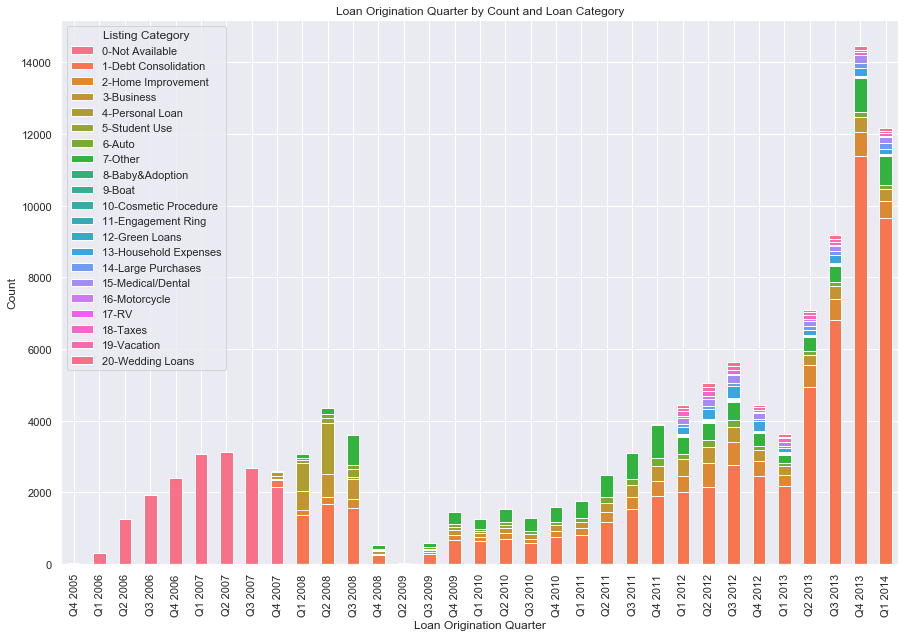

```python
#multivariate plot of listing category and counts per over time, create legend label descriptions
df_plot = prosperLoanData.groupby(['ListingCategory', 'LoanOriginationQuarter']).size().reset_index().pivot(columns='ListingCategory',
                                index='LoanOriginationQuarter', values=0)
df_plot.plot(kind='bar', stacked=True)

plt.legend(['0-Not Available', '1-Debt Consolidation', '2-Home Improvement', '3-Business', '4-Personal Loan',
              '5-Student Use', '6-Auto', '7-Other', '8-Baby&Adoption', '9-Boat', '10-Cosmetic Procedure',
              '11-Engagement Ring', '12-Green Loans', '13-Household Expenses', '14-Large Purchases','15-Medical/Dental',
              '16-Motorcycle', '17-RV', '18-Taxes', '19-Vacation', '20-Wedding Loans'], title='Listing Category')

sns.set(rc={'figure.figsize':(15, 10)})
sns.set_palette('husl', 20)
plt.title('Loan Origination Quarter by Count and Loan Category')
plt.ylabel('Count')
plt.xlabel('Loan Origination Quarter');
```

Prior to 2008, it looks like prosper did not capture the loan category, and debt consolidation dominated the category subsequently every year.

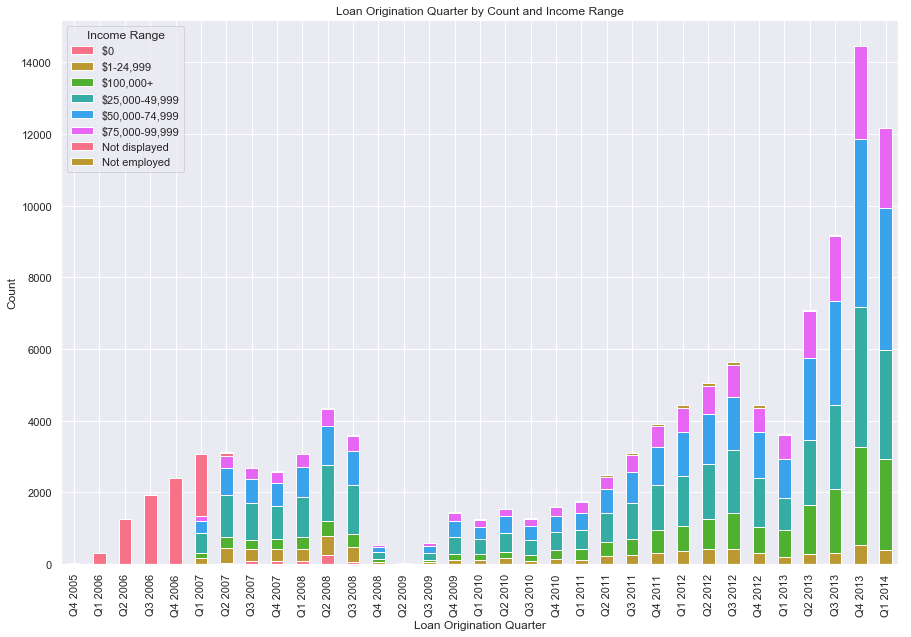

```python
#multivariate plot of income range and count per over time in order categorical type
quarter = ['Q4 2005', 'Q1 2006', 'Q2 2006', 'Q3 2006', 'Q4 2006', 'Q1 2007', 'Q2 2007', 'Q3 2007', 'Q4 2007', 'Q1 2008', 'Q2 2008', 'Q3 2008', 'Q4 2008',
          'Q2 2009', 'Q3 2009', 'Q4 2009', 'Q1 2010', 'Q2 2010', 'Q3 2010', 'Q4 2010', 'Q1 2011', 'Q2 2011', 'Q3 2011', 'Q4 2011', 'Q1 2012', 'Q2 2012', 'Q3 2012', 'Q4 2012',
          'Q1 2013', 'Q2 2013', 'Q3 2013', 'Q4 2013', 'Q1 2014']
qrt_cat = pd.api.types.CategoricalDtype(ordered = True, categories = quarter)
prosperLoanData['LoanOriginationQuarter'] = prosperLoanData['LoanOriginationQuarter'].astype(qrt_cat)

prosperLoanData = prosperLoanData.loc[prosperLoanData['LoanOriginationQuarter'].isin(['Q4 2005', 'Q1 2006', 'Q2 2006', 'Q3 2006', 'Q4 2006', 'Q1 2007', 'Q2 2007', 'Q3 2007', 'Q4 2007', 'Q1 2008', 'Q2 2008', 'Q3 2008', 'Q4 2008',
          'Q2 2009', 'Q3 2009', 'Q4 2009', 'Q1 2010', 'Q2 2010', 'Q3 2010', 'Q4 2010', 'Q1 2011', 'Q2 2011', 'Q3 2011', 'Q4 2011', 'Q1 2012', 'Q2 2012', 'Q3 2012', 'Q4 2012',
          'Q1 2013', 'Q2 2013', 'Q3 2013', 'Q4 2013', 'Q1 2014'])]

sns.set(rc={'figure.figsize':(15, 10)})
sns.set_palette('husl')
qrt_plot = prosperLoanData.groupby(['IncomeRange', 'LoanOriginationQuarter']).size().reset_index().pivot(columns='IncomeRange',
                                index='LoanOriginationQuarter', values=0)
qrt_plot.plot(kind='bar', stacked=True)
plt.legend(title='Income Range')
plt.title('Loan Origination Quarter by Count and Income Range')
plt.ylabel('Count')
plt.xlabel('Loan Origination Quarter');
```

It looks like the income ranges uptick in loans in 2012-2013. It grew initially in 50k-75k, 75k-100k, and 100k+.

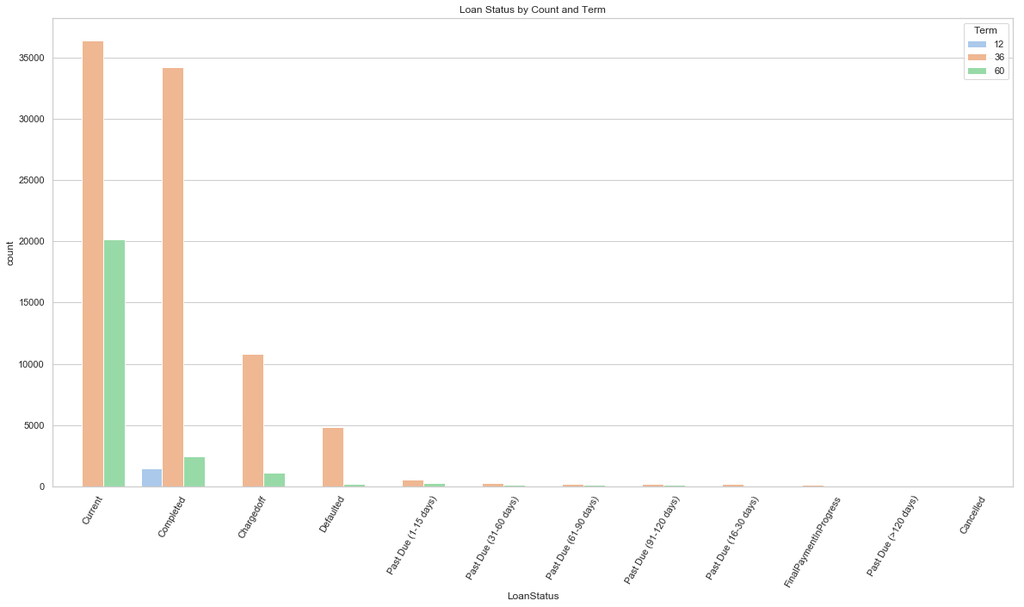

```python
#multivariate plot of loan status and count per term
fig = plt.figure(figsize = [20,10])
sns.set(style="whitegrid")
cat_order = prosperLoanData['LoanStatus'].value_counts().index
sb.countplot(data = prosperLoanData , x = 'LoanStatus', hue='Term', palette ='pastel', order = cat_order)
plt.title('Loan Status by Count and Term')
plt.legend(title='Term', loc='upper right')
plt.xticks(rotation=60);
```

It shows the majority of the loans are with 3-year term and they are mostly the current and completed loans.

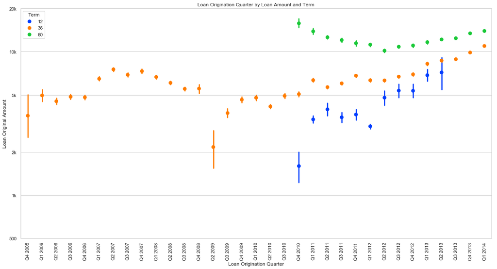

```python
#multivariate plot of loan original amount and term per over time in order categorical type
quarter = ['Q4 2005', 'Q1 2006', 'Q2 2006', 'Q3 2006', 'Q4 2006', 'Q1 2007', 'Q2 2007', 'Q3 2007', 'Q4 2007', 'Q1 2008', 'Q2 2008', 'Q3 2008', 'Q4 2008',
          'Q2 2009', 'Q3 2009', 'Q4 2009', 'Q1 2010', 'Q2 2010', 'Q3 2010', 'Q4 2010', 'Q1 2011', 'Q2 2011', 'Q3 2011', 'Q4 2011', 'Q1 2012', 'Q2 2012', 'Q3 2012', 'Q4 2012',
          'Q1 2013', 'Q2 2013', 'Q3 2013', 'Q4 2013', 'Q1 2014']
qrt_cat = pd.api.types.CategoricalDtype(ordered = True, categories = quarter)
prosperLoanData['LoanOriginationQuarter'] = prosperLoanData['LoanOriginationQuarter'].astype(qrt_cat)

prosperLoanData = prosperLoanData.loc[prosperLoanData['LoanOriginationQuarter'].isin(['Q4 2005', 'Q1 2006', 'Q2 2006', 'Q3 2006', 'Q4 2006', 'Q1 2007', 'Q2 2007', 'Q3 2007', 'Q4 2007', 'Q1 2008', 'Q2 2008', 'Q3 2008', 'Q4 2008',
          'Q2 2009', 'Q3 2009', 'Q4 2009', 'Q1 2010', 'Q2 2010', 'Q3 2010', 'Q4 2010', 'Q1 2011', 'Q2 2011', 'Q3 2011', 'Q4 2011', 'Q1 2012', 'Q2 2012', 'Q3 2012', 'Q4 2012',
          'Q1 2013', 'Q2 2013', 'Q3 2013', 'Q4 2013', 'Q1 2014'])]

fig = plt.figure(figsize = [20,10])
sns.set(style="whitegrid")
ax = sb.pointplot(data = prosperLoanData, x = 'LoanOriginationQuarter', y='LoanOriginalAmount', hue = 'Term',
           palette = 'bright', linestyles = '')
plt.title('Loan Origination Quarter by Loan Amount and Term')
plt.xlabel('Loan Origination Quarter')
plt.ylabel('Loan Original Amount')
plt.yscale('log')
plt.yticks([500, 1e3, 2e3, 5e3, 1e4, 2e4], ['500', '1k', '2k', '5k', '10k', '20k'])
plt.legend(title='Term', loc='upper left')
plt.xticks(rotation=90);
```

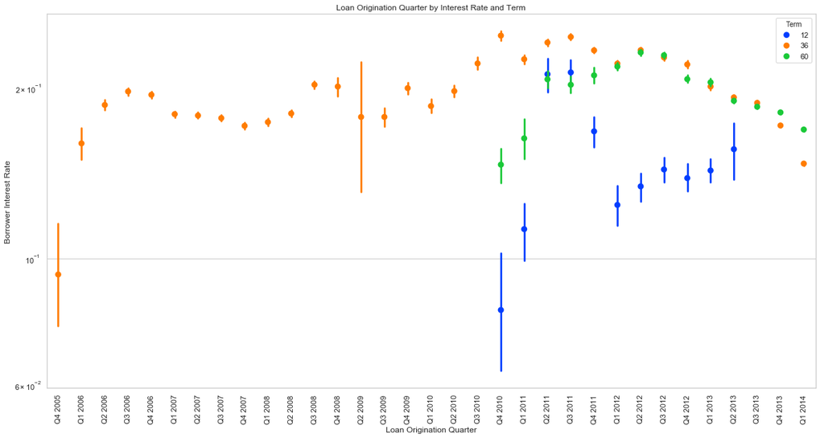

```python
#multivariate plot of interest rate and term per over time in order categorical type
quarter = ['Q4 2005', 'Q1 2006', 'Q2 2006', 'Q3 2006', 'Q4 2006', 'Q1 2007', 'Q2 2007', 'Q3 2007', 'Q4 2007', 'Q1 2008', 'Q2 2008', 'Q3 2008', 'Q4 2008',
          'Q2 2009', 'Q3 2009', 'Q4 2009', 'Q1 2010', 'Q2 2010', 'Q3 2010', 'Q4 2010', 'Q1 2011', 'Q2 2011', 'Q3 2011', 'Q4 2011', 'Q1 2012', 'Q2 2012', 'Q3 2012', 'Q4 2012',
          'Q1 2013', 'Q2 2013', 'Q3 2013', 'Q4 2013', 'Q1 2014']
qrt_cat = pd.api.types.CategoricalDtype(ordered = True, categories = quarter)
prosperLoanData['LoanOriginationQuarter'] = prosperLoanData['LoanOriginationQuarter'].astype(qrt_cat)

prosperLoanData = prosperLoanData.loc[prosperLoanData['LoanOriginationQuarter'].isin(['Q4 2005', 'Q1 2006', 'Q2 2006', 'Q3 2006', 'Q4 2006', 'Q1 2007', 'Q2 2007', 'Q3 2007', 'Q4 2007', 'Q1 2008', 'Q2 2008', 'Q3 2008', 'Q4 2008',
          'Q2 2009', 'Q3 2009', 'Q4 2009', 'Q1 2010', 'Q2 2010', 'Q3 2010', 'Q4 2010', 'Q1 2011', 'Q2 2011', 'Q3 2011', 'Q4 2011', 'Q1 2012', 'Q2 2012', 'Q3 2012', 'Q4 2012',
          'Q1 2013', 'Q2 2013', 'Q3 2013', 'Q4 2013', 'Q1 2014'])]

fig = plt.figure(figsize = [20,10])
sns.set(style="whitegrid")
ax = sb.pointplot(data = prosperLoanData, x = 'LoanOriginationQuarter', y = 'BorrowerRate', hue = 'Term',
           palette = 'bright', linestyles = '')
plt.title('Loan Origination Quarter by Interest Rate and Term')
plt.ylabel('Borrower Interest Rate')
plt.xlabel('Loan Origination Quarter')
plt.yscale('log')
plt.xticks(rotation=90);
```

A dodge point plot shows the clear influence of borrower interest rate and term in over time. There is a correlation between interest rate and terms (36 and 60) from year 2012 to 2014 where shows the 36 term is not necessarily more expensive.

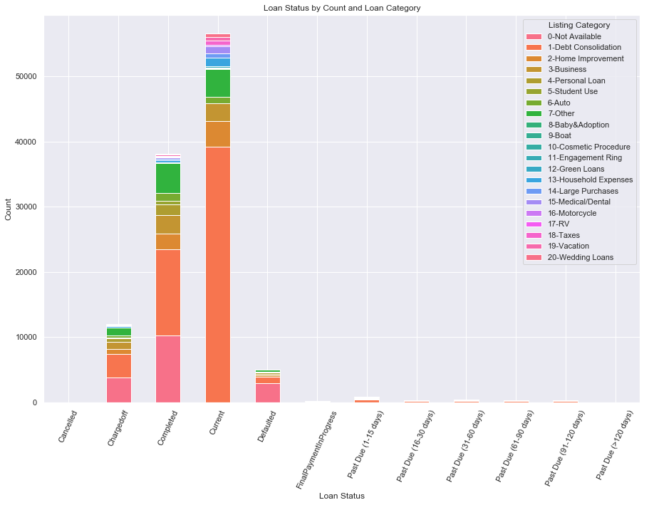

```python
#multivariate plot of listing category and count per loan status, create legend label descriptions
sns.set(rc={'figure.figsize':(15, 10)})
sns.set_palette('husl', 20)
df_plot = prosperLoanData.groupby(['ListingCategory', 'LoanStatus']).size().reset_index().pivot(columns='ListingCategory',
                                index='LoanStatus', values=0)
df_plot.plot(kind='bar', stacked=True)

plt.legend(['0-Not Available', '1-Debt Consolidation', '2-Home Improvement', '3-Business', '4-Personal Loan',
              '5-Student Use', '6-Auto', '7-Other', '8-Baby&Adoption', '9-Boat', '10-Cosmetic Procedure',
              '11-Engagement Ring', '12-Green Loans', '13-Household Expenses', '14-Large Purchases','15-Medical/Dental',
              '16-Motorcycle', '17-RV', '18-Taxes', '19-Vacation', '20-Wedding Loans'], title='Listing Category')
plt.title('Loan Status by Count and Loan Category')
plt.ylabel('Count')
plt.xlabel('Loan Status')
plt.xticks(rotation=65);
```

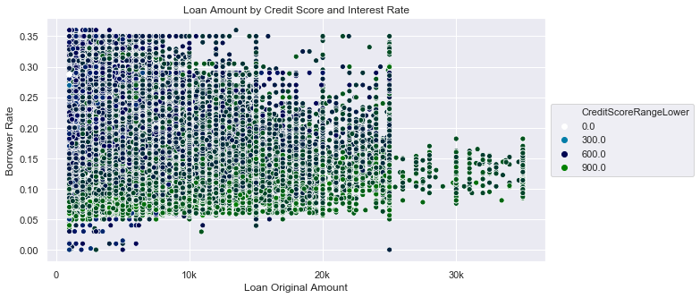

```python
#multivariate plot of interest rate and credit score per loan amount
plt.figure(figsize = [10, 5])
sns.scatterplot(x='LoanOriginalAmount', y='BorrowerRate', hue='CreditScoreRangeLower', palette='ocean_r', data=prosperLoanData);
plt.xticks([0, 1e4, 2e4, 3e4], ['0', '10k', '20k', '30k'])
plt.title('Loan Amount by Credit Score and Interest Rate')
plt.xlabel('Loan Original Amount')
plt.ylabel('Borrower Rate')
plt.legend(loc='center left', bbox_to_anchor=(1, 0.5));
```

The borrowers with high credit scores are with lower interest rates and mostly with larger loan amounts (bottom right.)

### Were there any interesting or surprising interactions between features?

> Prior to 2008, it looks like prosper did not capture the loan category, and debt consolidation dominated the category subsequently every year. The influence of borrower interest rate and term in over time was clear. There was a correlation between interest rate and terms (36 and 60) from year 2012 to 2014 where the 36 term is not necessarily more expensive. I saw the prosper struggle initially with their first few years of loans. But their business grew very quickly after the downturn and market fall by 2009. Their main loan exposures are in debt consolidation and I’m sure the low interest rate environment has helped the supply of lenders looking for yield. Also, the income ranges uptick in loans in 2012-2013. It grew initially in 50k-75k, 75k-100k, and 100k+.